# ps5-rmarkdown

Zerelda Mauricio

2023-02-19

### 1: Load and Check Data

**1.** Here is the rmarkdown document!

**2.**

```r
library(tidyverse)
getwd()
```

```
## [1] "/Users/zmauricio/Desktop/School/Info/201/REPOS/PS5-ZM-W-2023"
```

```r
gm <- read_delim("../../Data/gapminder.csv.bz2")
```

Inside the *gapminder* data, we have **13055** rows and **25** columns.

**3.**

```r
gm %>%
  sample_n(3) %>%
  knitr::kable()
```

| iso3 | name | iso2 | region | sub-region | intermediate-region | time | totalPopulation | fertilityRate | lifeExpectancy | childMortality | youthFemaleLiteracy | youthMaleLiteracy | adultLiteracy | GDP_PC | accessElectricity | agriculturalLand | agricultureTractors | cerealProduction | fertilizerHa | co2 | greenhouseGases | co2_PC | pm2.5_35 | battleDeaths |
| --- | --- | --- | --- | --- | --- | --- | --- | --- | --- | --- | --- | --- | --- | --- | --- | --- | --- | --- | --- | --- | --- | --- | --- | --- |
| JPN | Japan | JP | Asia | Eastern Asia | NA | 1961 | 94943000 | 2.050 | 68.310 | 36.2 | NA | NA | NA | 9396.221 | NA | 71100 | 6978 | 20318660 | 279.88869 | 283118.069 | NA | 2.98198 | NA | NA |
| NRU | Nauru | NR | Oceania | Micronesia | NA | 1995 | 10628 | NA | NA | 49.3 | NA | NA | NA | NA | NA | 4 | NA | NA | NA | 106.343 | NA | 10.00593 | NA | NA |
| LBY | Libya | LY | Africa | Northern Africa | NA | 1988 | 4220450 | 5.533 | 67.775 | 46.4 | NA | NA | NA | NA | NA | 154400 | 29216 | 283231 | 48.83333 | 36398.642 | 55358.71 | 8.62435 | NA | NA |

The sample data looks ok, so I think the dataframe is good!

### 2: Descriptive Statistics

**1.**

```r
gm %>%
  select(iso3, name, iso2) %>%
  summarise(countryNum = n_distinct(name), iso2Num = n_distinct(iso2),
            iso3Num = n_distinct(iso3)) %>%
  knitr::kable()
```

| countryNum | iso2Num | iso3Num |
| --- | --- | --- |
| 250 | 249 | 253 |

**2.** What is going on seems to be that the function counting the number of distinctions between country codes is also counting the number of “NA” values available, which distorts each of the possible values.

- **a)**

```r
iso2Count <- gm %>%
  group_by(iso2) %>%
  select(name, iso2) %>%
  summarise(iso2Num = n_distinct(name)) %>%
  arrange(desc(iso2Num)) %>%
  head(1)
```

The only iso2 code that seems to contain more than one name is the value *[Country, Region]*: **NA, 2.**

- **b)**

```r
gm %>%
  group_by(iso3) %>%
  filter(is.na(name)) %>%
  summarize(iso3Num = n_distinct(iso3)) %>%
  select(iso3)
```

```
## # A tibble: 4 × 1
##   iso3
##   <chr>
## 1 CHANISL
## 2 GBM
## 3 KOS
## 4 NLD_CURACAO
```

**3.**

```r
latest <- gm %>%
  select(time) %>%
  arrange(desc(time)) %>%
  head(1)

latest
```

```
## # A tibble: 1 × 1
##    time
##   <dbl>
## 1  2019
```

```r
earliest <- gm %>%
  select(time) %>%
  arrange(time) %>%
  head(1)

earliest
```

```
## # A tibble: 1 × 1
##    time
##   <dbl>
## 1  1960
```

The minimum, or earliest year in the data, is **1960,** while the maximum or latest year is **2019.**

### 3: CO2 Emissions

**1.**

```r
gm %>%
  group_by(time) %>%
  summarize(naVal = sum(is.na(co2)), naVal2 = sum(is.na(co2_PC))) %>%
  arrange(desc(naVal)) %>%
  head(5)
```

```
## # A tibble: 5 × 3
##    time naVal naVal2
##   <dbl> <int>  <int>
## 1  2017   217    217
## 2  2018   217    217
## 3  2019   217    217
## 4  1960    60     60
## 5  1961    60     60
```

The years that seem to have the most missing are **2017 through 2019,** having *217 missing values,* followed by the earliest years, **starting at 1960,** with *60 missing values.* Why 2017 through 2019 have so many missing values, I do not know.

(I was told by a TA that all of my calculations are correct, but that my co2_PC [aka naVal2] should not be displaying any NA values. They could not figure out why both display the same amount of NA values, but they verified that my pipe loop was correct.)

**2.**

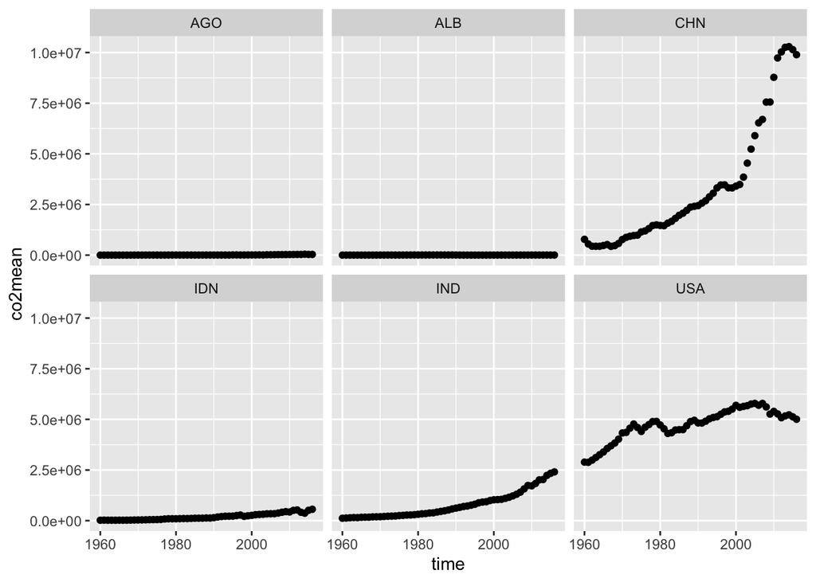

```r
co2Total <- gm %>%
  group_by(iso3, time) %>%
  filter(!is.na(co2), !is.na(name)) %>%
  summarize(co2mean = mean(co2)) %>%
  filter(iso3 == "USA" | iso3 == "CHN" | iso3 == "IND" | iso3 == "IDN"
         | iso3 == "ALB" | iso3 == "AGO")

ggplot(data = co2Total) +
      geom_point(mapping = aes(time, co2mean)) +
      facet_wrap(~iso3)
```

**3.**

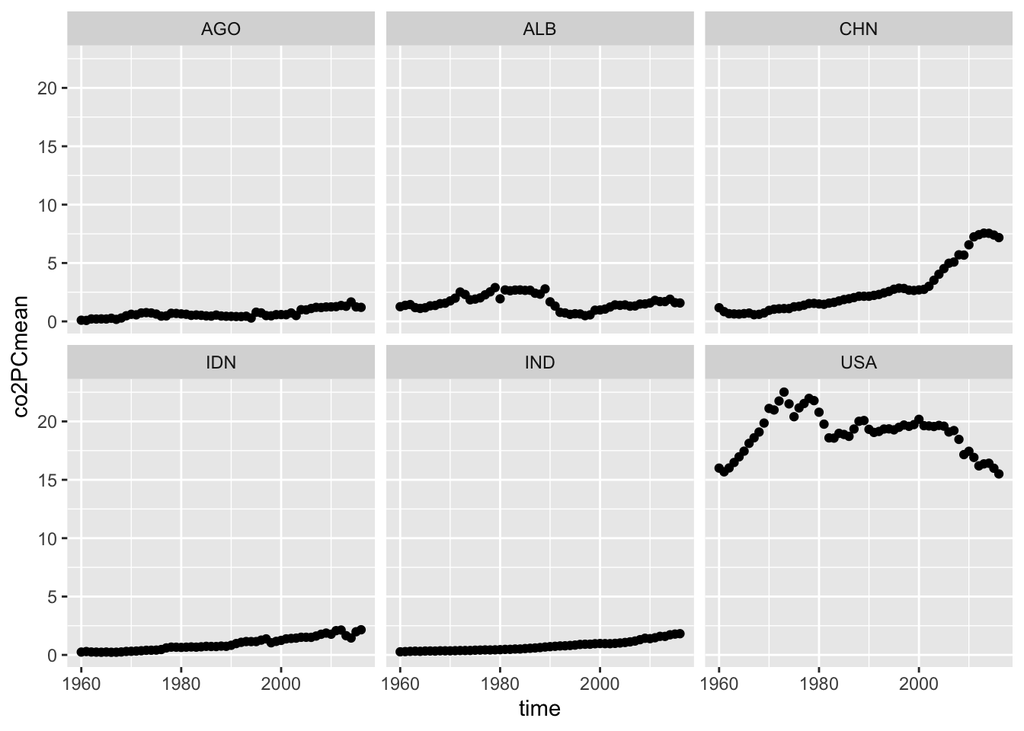

```r
co2PCTotal <- gm %>%
  group_by(iso3, time) %>%
  filter(!is.na(co2_PC), !is.na(name)) %>%
  summarize(co2PCmean = mean(co2_PC)) %>%
  filter(iso3 == "USA" | iso3 == "CHN" | iso3 == "IND" | iso3 == "IDN"
         | iso3 == "ALB" | iso3 == "AGO")

ggplot(data = co2PCTotal) +
      geom_point(mapping = aes(time, co2PCmean)) +
      facet_wrap(~iso3)
```

This is, like the last graph, scatter plots depicting the CO2 emissions *per capita* over time for the US, China, India, Indonesia, Albania, and Angola between the years of 1960 and 2019. There is a stark contrast here with the last graph in the sense that while the *last* graph showed that China produced the most CO2 in the current day, *this* graph shows that the US has the most emissions. This suggests that though China produces more overall, it is more concentrated to areas of intense production or concentrated blocks of factories. We can see that for the US, there is a much more *consistent* and *higher* rate of CO2 emission for each area, producing CO2 everywhere at a larger capacity on average than China.

**4.**

```r
gm %>%
  select(region, co2_PC, time) %>%
  filter(time == "2016" | time == "1960") %>%
  filter(!is.na(co2_PC), !is.na(region)) %>%
  group_by(region, time) %>%
  summarize(co2mean = mean(co2_PC))
```

```
## # A tibble: 10 × 3
## # Groups:   region [5]
##    region    time co2mean
##    <chr>    <dbl>   <dbl>
##  1 Africa    1960   0.291
##  2 Africa    2016   1.20
##  3 Americas  1960   7.15
##  4 Americas  2016   4.80
##  5 Asia      1960   1.74
##  6 Asia      2016   6.47
##  7 Europe    1960   5.77
##  8 Europe    2016   6.64
##  9 Oceania   1960   2.73
## 10 Oceania   2016   4.57
```

**5.**

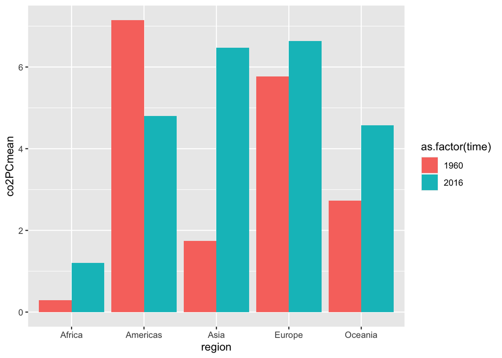

```r
comparison <- gm %>%
  group_by(region, time) %>%
  filter(!is.na(co2_PC), !is.na(name)) %>%
  summarize(co2PCmean = mean(co2_PC)) %>%
  filter(time == 1960 | time == 2016)

ggplot(data = comparison,
       aes(x = region, y = co2PCmean, fill = as.factor(time))) +
  geom_bar(stat = "identity", position = "dodge")
```

This barplot shows the previous results–average CO2 emissions per capita across continents in 1960 and 2016. **Africa** has the *lowest* overall average, while **Europe** goes on to beat out America’s average in 2016 despite **America** being the far *greater CO2 emitter during 1960.*

**6.** I was informed for number 6 that *due to the high amount of missing values for 2019, 2016 should be used instead.* I have codes for both:

CODE FOR CO2 EMITTERS FOR 2019

```r
gm %>%
  group_by(region) %>%
  filter(!is.na(co2_PC), !is.na(name), !is.na(region)) %>%
  filter(time == "2019") %>%
  select(region, name, co2_PC) %>%
  filter(rank(desc(co2_PC)) < 4 | rank(co2_PC) < 4) %>%
  mutate(rank = row_number()) %>%
  arrange(region, co2_PC)
```

```
## # A tibble: 0 × 4
## # Groups:   region [0]
## # … with 4 variables: region <chr>, name <chr>, co2_PC <dbl>, rank <int>
```

CODE FOR CO2 EMITTERS FOR 2016

```r
gm %>%
  group_by(region) %>%
  filter(!is.na(co2_PC), !is.na(name), !is.na(region)) %>%
  filter(time == "2016") %>%
  select(region, name, co2_PC) %>%
  filter(rank(desc(co2_PC)) < 4 | rank(co2_PC) < 4) %>%
  mutate(rank = row_number()) %>%  ##debugging to check
  arrange(region, co2_PC)
```

```
## # A tibble: 30 × 4
## # Groups:   region [5]
##    region   name                               co2_PC  rank
##    <chr>    <chr>                               <dbl> <int>
##  1 Africa   Congo, Democratic Republic of the  0.0256     2
##  2 Africa   Somalia                            0.0455     4
##  3 Africa   Burundi                            0.0472     1
##  4 Africa   Seychelles                         6.39       5
##  5 Africa   Libya                              7.79       3
##  6 Africa   South Africa                       8.48       6
##  7 Americas Haiti                              0.275      3
##  8 Americas Nicaragua                          0.887      4
##  9 Americas Honduras                           1.06       2
## 10 Americas Canada                            15.1        1
## # … with 20 more rows
```

### 4: GDP per Capita

**1.**

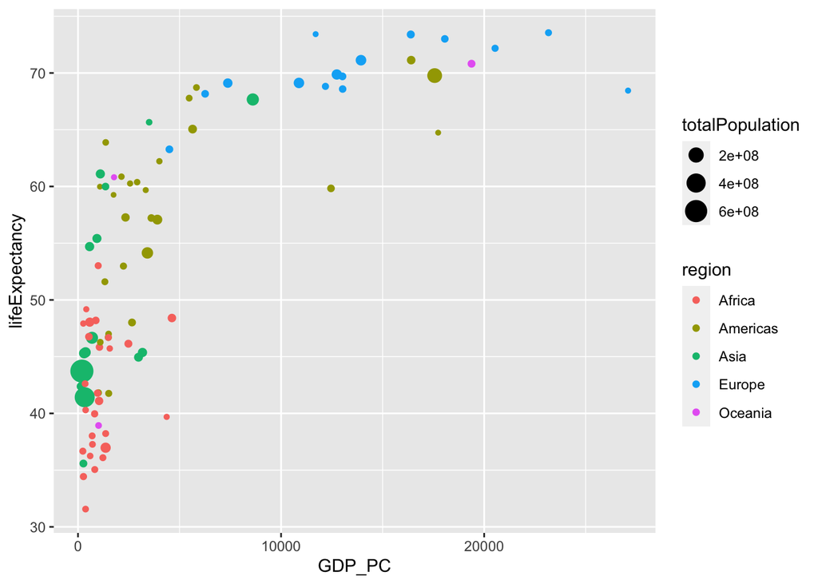

```r
GDP <- gm %>%
  group_by(name) %>%
  filter(!is.na(GDP_PC) & !is.na(lifeExpectancy)) %>%
  select(region, GDP_PC, lifeExpectancy, time, totalPopulation) %>%
  filter(time == "1960")

ggplot(data = GDP) +
  geom_point(mapping = aes(x = GDP_PC, y = lifeExpectancy, color = region, size = totalPopulation))
```

There is a stark difference **around the 5000 GDP_PC mark.** Where the life expectancy could be anything for *those lower than ~5000 GDP per capita,* after 5000 it **sharply inclines** and then levels out around the 70-80 mark. It is interesting to note that country size does *not* seem to matter in relations to GDP, but *does* imply a higher baseline life expectancy (even if not by much, with expectancies as low as the 40 year mark).

**2.**

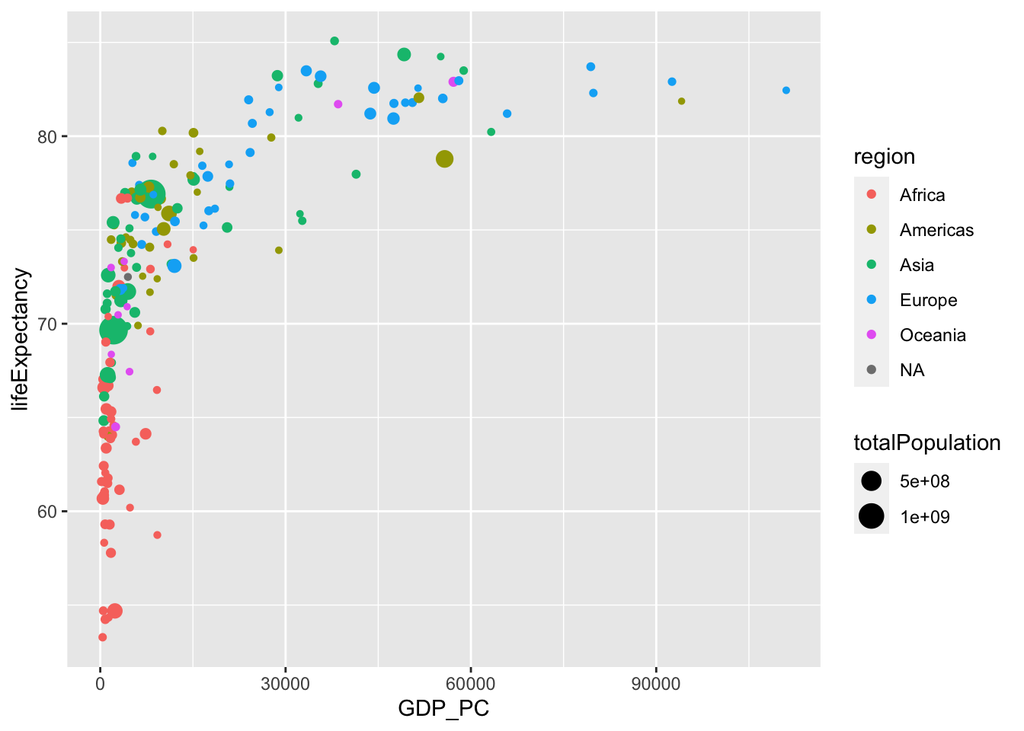

```r
GDP2019 <- gm %>%
  group_by(name) %>%
  filter(!is.na(GDP_PC) & !is.na(lifeExpectancy)) %>%
  select(region, GDP_PC, lifeExpectancy, time, totalPopulation) %>%
  filter(time == "2019")

ggplot(data = GDP2019) +
  geom_point(mapping = aes(x = GDP_PC, y = lifeExpectancy, color = region, size = totalPopulation))
```

It seems that more countries are present here with existing GDPs and reported life expectancies, and that the countries seem to be more sectioned off to their own sections. Many of the African countries do *not* have high life expectancies, none of the reported countries reaching above 80. While more countries have a larger population, the countries with preexisting large populations have moved up on the scale to have *longer* life expectancies.

**3.** While it looks like there is a more immediate incline for the 2019 graph that would indicate a higher life expectancy with a lower GDP, you can actually see that the 2019 graph has a much higher GDP limit. This implies that not only has inflation deeply affected the GDPs of nations worldwide, but also that the countries that are closer to 0 are susbsisting off of much less than they did before. Overall, 2019 has higher bounds for everything- a higher general life expectancy, and easily much higher GDPs. But this increase does not immediately imply a positive development, since the color coordination of the plot points show the the countries have become far more concentrated into specific continents dominating certain regions. This can especially be seen for Africa, which has been harshly relegated to both having generally lower GDPs and lower life expectancies.

**4.**

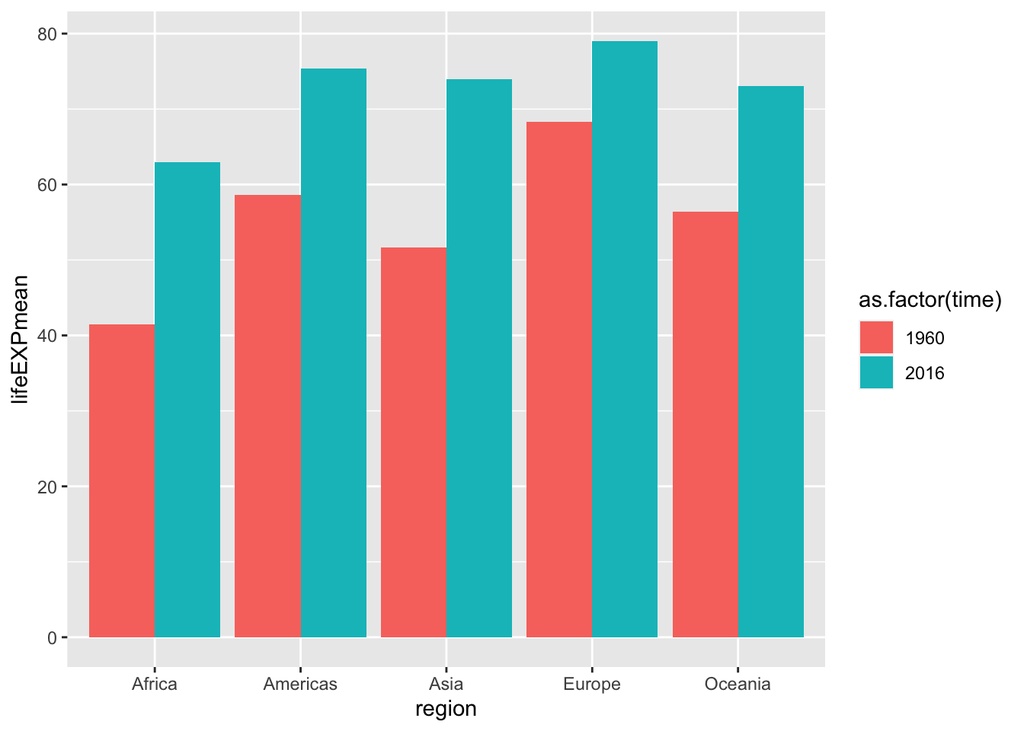

```r
lifeComp <- gm %>%
  group_by(region, time) %>%
  filter(!is.na(lifeExpectancy), !is.na(name)) %>%
  summarize(lifeEXPmean = mean(lifeExpectancy)) %>%
  filter(time == 1960 | time == 2016)

ggplot(data = lifeComp,
       aes(x = region, y = lifeEXPmean, fill = as.factor(time))) +
  geom_bar(stat = "identity", position = "dodge")
```

The figure seems to align pretty well with both of the two plots, with **Europe** having had the *highest life expectancy in 1960* in both the GDP plot and the LifeExp graph, and **Africa** having the *lowest life expectancy in 1960* according to the two figures. Another visual confirmation is that between the two figures, **all continents** have an *improved average life expectancy by 2016* in comparison to their 1960 versions.

**5.**

```r
gm %>%
  filter(time == "1960" | time == "2019") %>%
  filter(!is.na(lifeExpectancy) & !is.na(region)) %>%
  group_by(region, time) %>%
  summarize(lifeEXPMean = mean(lifeExpectancy)) %>%
  group_by(region) %>%
  summarize(growth = lifeEXPMean - lag(lifeEXPMean)) %>%
  filter(!is.na(growth)) %>%
  arrange(desc(growth))
```

```
## # A tibble: 5 × 2
## # Groups:   region [5]
##   region   growth
##   <chr>     <dbl>
## 1 Asia       23.0
## 2 Africa     22.6
## 3 Americas   17.2
## 4 Oceania    17.1
## 5 Europe     11.1
```

**6.** GDP Histogram of *all countries,* with 1960 and 2019 combined:

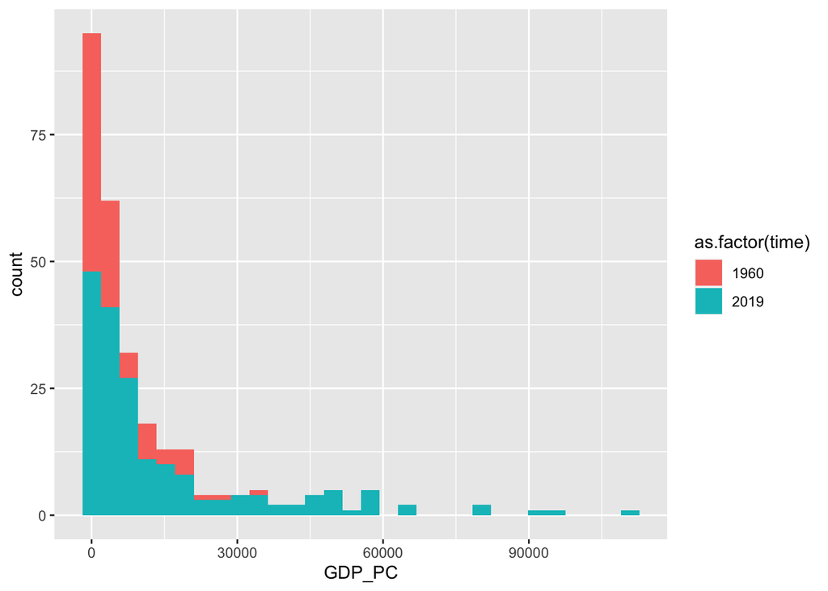

```r
gdpHist <- gm %>%
  group_by(region, time) %>%
  select(iso3, GDP_PC, time) %>%
  filter(!is.na(iso3), !is.na(GDP_PC)) %>%
  filter(time == "1960" | time == "2019")

ggplot(data = gdpHist,
       aes(x = GDP_PC, fill = as.factor(time))) +
  geom_histogram()
```

This is a histogram of *all countries* and their GDP comparisons between 1960 and 2019.

**7.** FOR LIFE EXPECTANCY IN 1960

```r
gm %>%
  select(name, lifeExpectancy, time) %>%
  filter(!is.na(name) & !is.na(time) & !is.na(lifeExpectancy)) %>%
  filter(time == "1960") %>%
  arrange(desc(lifeExpectancy)) %>%
  mutate(rank = row_number()) %>%
  filter(name == "United States of America")
```

```
## # A tibble: 1 × 4
##   name                     lifeExpectancy  time  rank
##   <chr>                             <dbl> <dbl> <int>
## 1 United States of America           69.8  1960    17
```

FOR LIFE EXPECTANCY IN 2019

```r
gm %>%
  select(name, lifeExpectancy, time) %>%
  filter(!is.na(name) & !is.na(time) & !is.na(lifeExpectancy)) %>%
  filter(time == "2019") %>%
  arrange(desc(lifeExpectancy)) %>%
  mutate(rank = row_number()) %>%
  filter(name == "United States of America")
```

```
## # A tibble: 1 × 4
##   name                     lifeExpectancy  time  rank
##   <chr>                             <dbl> <dbl> <int>
## 1 United States of America           78.8  2019    46
```

The ranking of the US for 1960 was 17th place with a life expectancy of 69.7703, while its ranking for 2019 was 46th place with a life expectancy of 78.78780.

**8.** FOR LIFE EXPECTANCY *RANK* IN 1960

```r
gm %>%
  select(name, lifeExpectancy, time) %>%
  filter(!is.na(name) & !is.na(time) & !is.na(lifeExpectancy)) %>%
  filter(time == "1960") %>%
  arrange(desc(lifeExpectancy)) %>%
  mutate(rank = row_number()) %>%
  mutate(placement = rank / n()) %>%
  filter(name == "United States of America")
```

```
## # A tibble: 1 × 5
##   name                     lifeExpectancy  time  rank placement
##   <chr>                             <dbl> <dbl> <int>     <dbl>
## 1 United States of America           69.8  1960    17    0.0904
```

FOR LIFE EXPECTANCY *RANK* IN 2019

```r
gm %>%
  select(name, lifeExpectancy, time) %>%
  filter(!is.na(name) & !is.na(time) & !is.na(lifeExpectancy)) %>%
  filter(time == "2019") %>%
  arrange(desc(lifeExpectancy)) %>%
  mutate(rank = row_number()) %>%
  mutate(placement = rank / n()) %>%
  filter(name == "United States of America")
```

```
## # A tibble: 1 × 5
##   name                     lifeExpectancy  time  rank placement
##   <chr>                             <dbl> <dbl> <int>     <dbl>
## 1 United States of America           78.8  2019    46     0.235
```

The US has a relative rank placement of **0.234** for 2019.

**TOTAL TIME SPENT ON THIS PS:** I spent 10 hours on this problem set.